# DMHR Assignment

## Part A: NHS Prescribing

Unnecessary prescriptions increase waste, are harmful to patients and are costly to the NHS, as well as contributing to issues such as antimicrobial resistance. One of the first steps in reducing unnecessary prescriptions at a large scale is to examine patterns in prescribing data across GPs, where most prescription occurs. This report explores prescription in London and Cambridge practices in 04/2018 before exploring national prescribing in all practices for cardiovascular drugs and antidepressant drugs. Finally, prescriptions across England are explored. Variation in prescribing practice could be used to inform policy to improve practice and increase efficiency.

### Set up & background

Data for prescribing by practice was taken from NHS Digital and combined with NHS Digital GPs population address details.

```python
# import modules
import numpy as np
import pandas as pd
import matplotlib.pyplot as plt
from scipy import stats
from pandasql import sqldf
pysqldf = lambda q: sqldf(q, globals())
import re
```

```python
# import addresses
colnames = ["DATE", "CODE", "NAME", "ADD1", "ADD2", "ADD3", "ADD4", "POSTCODE"]
add_raw = pd.read_csv("T201804ADDR+BNFT.csv", header = None, names = colnames)
add_raw = add_raw.apply(lambda x: x.str.strip() if x.dtype == "object" else x)

# filter to address data to London & Cambridge only
## some practices contain the city in ADD4 while others have it in ADD3 so both have been used
## exact matching has been used in most cases to ensure insitsnces such as 'London Road' are not returned
## further details can be found in the sections for the respective areas
add_ldn = add_raw[add_raw['ADD4'].str.contains('LONDON') | (add_raw['ADD3'] == 'LONDON')]
add_cbg = add_raw.loc[(add_raw['ADD3'] == 'CAMBRIDGE') | (add_raw['ADD4'] == 'CAMBRIDGE')]
```

```python
# import prescribing data
colnames = ['SHA', 'PCT', 'CODE', 'BNFCODE', 'BNFNAME', 'ITEMS', 'NIC', 'ACTCOST', 'QUANTITY', 'PERIOD']
scrips_raw = pd.read_csv('T201804PDPI+BNFT.csv', header = 0, names = colnames, index_col=False)
pop_raw = pd.read_csv('gp-reg-pat-prac-all.csv')
```

```python
# add total cost column
scrips_raw.loc[:,'TOTALCOST'] = scrips_raw['ITEMS'] * scrips_raw['ACTCOST']
```

Some records in the prescription data are for 'dummy' practices created to account for prescriptions in primary care outside of general practices (e.g. prisons, hospices etc.). This leads to a mismatch in the number of providers when compared to other data sets such as population. The population data will be used as the definitive list of active, primary care general practices and the address data will be used to subset this into a list of codes for the areas of interest. Because branch practices may be recorded differently in different datasets it is possible that mismatches will still occur.

```python
# define columns of interest
cols = ['CODE', 'NAME', 'NUMBER_OF_PATIENTS', 'BNFCODE', 'BNFNAME', 'ITEMS', 'ACTCOST', 'QUANTITY', 'TOTALCOST']

# get London data
ldn = pd.merge(pd.merge(add_ldn, scrips_raw, on='CODE', how='inner'), pop_raw, on='CODE', how = 'inner')
ldn = ldn[cols]

# get Cambridge data
cbg = pd.merge(pd.merge(add_cbg, scrips_raw, on='CODE', how='inner'), pop_raw, on='CODE', how = 'inner')
cbg = cbg[cols]
```

### London

London practices are identified as:

- London (exact match) in the third address attribute ('add3') because some records do not have data in the fourth address column. An exact match is used to avoid including practices that are located on roads such as 'London Road' which may not be in London.
- London contained in the fourth address attribute ('add4') because some records hold both the area of London and London in this attribute (e.g. 'FINCHLEY LONDON')

It is possible that some London practices have been unintentionally excluded or non-London practices included however by using relatively restrictive rules this risk is minimised to the extent that the data allows.

The list of practices was further reduced to include only those where population data for April 2018 was present. This ensures consistency between analyses as well as helping reduce the number of non-general practices in the prescribing data.

```python
# details of matching
print('While', add_ldn['CODE'].nunique() ,'practices where identified from the address lookup as in London, only', ldn['CODE'].nunique(),
      'of these where present in the population data. This may reflect practices in the address data that are dummy practices, not general practices, have closed or are dormant or practices that are missing population data.')
```

```
While 943 practices where identified from the address lookup as in London, only 761 of these where present in the population data. This may reflect practices in the address data that are dummy practices, not general practices, have closed or are dormant or practices that are missing population data.
```

```python
# summary of London GP pop
print('The total number of patients registered at the ', ldn['CODE'].nunique(),
      ' GP practices in London during April 2018 was ', ldn.groupby('CODE')['NUMBER_OF_PATIENTS'].first().sum(),
      '. The average practice had ', round(ldn.groupby('CODE')['NUMBER_OF_PATIENTS'].first().mean()),
      ' patients registered but this is skewed by a few large practices.',
      ' The median number of patients registered per practice is ', ldn.groupby('CODE')['NUMBER_OF_PATIENTS'].first().median(),
      '. As can be seen in the following summary statistics and histogram the range between practices is quite large.'
      , sep='')

ldn.groupby('CODE')['NUMBER_OF_PATIENTS'].first().describe()
```

[output not shown]

```
count      761.000000
mean      7831.618922
std       5030.513284
min          8.000000
25%       4570.000000
50%       7050.000000
75%      10225.000000
max      72227.000000
Name: NUMBER_OF_PATIENTS, dtype: float64
```

[figure not shown]

```python
# hist of London pop, exlcuding 0.01 outliers
min_x = ldn.groupby('CODE')['NUMBER_OF_PATIENTS'].first().quantile(.01)
max_x = ldn.groupby('CODE')['NUMBER_OF_PATIENTS'].first().quantile(.99)
_ = plt.hist(ldn.groupby('CODE')['NUMBER_OF_PATIENTS'].first(), bins = 40)
_ = plt.xlim(min_x, max_x)
_ = plt.title('Number of patients registered at GP Practices in London, April 2018')
_ = plt.xlabel('Number of practices (excluding outliers)')
_ = plt.ylabel('Number of patients')
```

##### Prescriptions

```python
# group prescribing data by practice
ldn_prac_grouped = ldn.drop(['ACTCOST'], axis=1).groupby(['CODE', 'NAME', 'NUMBER_OF_PATIENTS']).sum().reset_index('NUMBER_OF_PATIENTS')

# group prescribing data by BNFCODE
ldn_bnf_grouped = ldn.drop(['NUMBER_OF_PATIENTS', 'ACTCOST'], axis=1).groupby(['BNFCODE', 'BNFNAME']).sum().reset_index('BNFCODE')
```

```python
# summary of London GP scrips
print('Within London ', np.sum(ldn['ITEMS']), ' prescriptions for ', ldn['BNFCODE'].nunique(), ' different items were given out in April 2018 ',
      'at a total cost of £', round(np.sum(ldn['TOTALCOST']),2), '. This means across London the average number of prescriptions per patient was ',
      round(np.sum(ldn['ITEMS']) / ldn.groupby('CODE')['NUMBER_OF_PATIENTS'].first().sum(), 2), '. On average each patient cost £',
      round(np.sum(ldn['TOTALCOST']) / ldn.groupby('CODE')['NUMBER_OF_PATIENTS'].first().sum(),2), ' with each costing on average £',
      round(np.mean(ldn['ACTCOST']),2), '.',
      sep = '')

ldn.groupby('CODE').first().describe()
```

```
Within London 5941115 prescriptions for 13054 different items were given out in April 2018 at a total cost of £1022776544.92. This means across London the average number of prescriptions per patient was 1.0. On average each patient cost £171.61 with each costing on average £54.26.
```

|  | NUMBER_OF_PATIENTS | ITEMS | ACTCOST | QUANTITY | TOTALCOST |
| --- | --- | --- | --- | --- | --- |
| count | 761.000000 | 761.000000 | 761.000000 | 761.000000 | 761.000000 |
| mean | 7831.618922 | 2.864652 | 24.386413 | 1331.244415 | 133.508239 |
| std | 5030.513284 | 4.076418 | 63.351682 | 2213.847171 | 459.503700 |
| min | 8.000000 | 1.000000 | 0.290000 | 14.000000 | 0.290000 |
| 25% | 4570.000000 | 1.000000 | 2.790000 | 224.000000 | 2.790000 |
| 50% | 7050.000000 | 1.000000 | 6.460000 | 500.000000 | 10.100000 |
| 75% | 10225.000000 | 3.000000 | 18.700000 | 1300.000000 | 51.920000 |
| max | 72227.000000 | 32.000000 | 739.120000 | 16350.000000 | 5007.040000 |

When looking at the average of practices (as opposed to the population overall) we can see that there was large range in the average number and total cost of prescriptions across the practices.

There is considerable variation between practices in the number of items prescribed and the cost of the items prescribed. There could be several reasons for this such as number of patients and type of medications prescribed. To explore these differences we can look at prescriptions by the registered population.

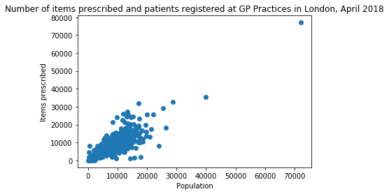

```python
# scatter of pop vs scrips
_ = plt.scatter(ldn_prac_grouped['NUMBER_OF_PATIENTS'], ldn_prac_grouped['ITEMS'])
_ = plt.title('Number of items prescribed and patients registered at GP Practices in London, April 2018')
_ = plt.xlabel('Population')
_ = plt.ylabel('Items prescribed')
```

This suggests much of the variation in the number of items prescribed is due to the number of patients

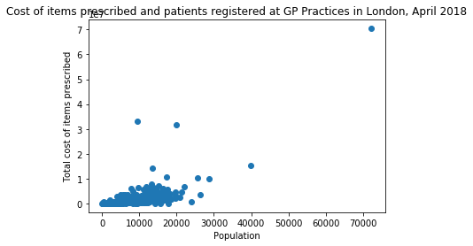

```python
# scatter of pop vs scrip cost
_ = plt.scatter(ldn_prac_grouped['NUMBER_OF_PATIENTS'], ldn_prac_grouped['TOTALCOST'])
_ = plt.title('Cost of items prescribed and patients registered at GP Practices in London, April 2018')
_ = plt.xlabel('Population')
_ = plt.ylabel('Total cost of items prescribed')
```

However, the cost of prescriptions appears to be less correlated with practice size suggesting there may be differences in prescribing practice between GPs or differences in the needs of patients between practices, for example a tendency to prescribe more expensive items and (as opposed to simply more) would increase costs. Work could be undertaken to explore if more cost-effective items could be substituted for more costly items. There may be particular items that account for much of the expenditure.

```python
# most commly prescribed
print('The 10 most prescribed items were:')
ldn_bnf_grouped.sort_values('ITEMS', axis=0, ascending=False, kind='quicksort', na_position='last').head(10)
```

```
The 10 most prescribed items were:
```

| BNFNAME | BNFCODE | ITEMS | QUANTITY | TOTALCOST |
| --- | --- | --- | --- | --- |
| Omeprazole_Cap E/C 20mg | 0103050P0AAAAAA | 125415 | 4752282 | 26772684.61 |
| Metformin HCl_Tab 500mg | 0601022B0AAABAB | 123250 | 11930509 | 97133900.72 |
| Amlodipine_Tab 5mg | 0206020A0AAAAAA | 105391 | 3807839 | 37651119.13 |
| Atorvastatin_Tab 20mg | 0212000B0AAABAB | 101891 | 3645805 | 19203632.58 |
| Amlodipine_Tab 10mg | 0206020A0AAABAB | 97798 | 3400459 | 38024034.00 |
| Atorvastatin_Tab 40mg | 0212000B0AAACAC | 92801 | 2702776 | 18814193.46 |
| Aspirin Disper_Tab 75mg | 0209000A0AAABAB | 89837 | 2480942 | 6275011.09 |
| Lansoprazole_Cap 30mg (E/C Gran) | 0103050L0AAAAAA | 89570 | 2570061 | 16989100.52 |
| Salbutamol_Inha 100mcg (200 D) CFF | 0301011R0AAAPAP | 81474 | 116861 | 28544957.38 |
| Paracet_Tab 500mg | 0407010H0AAAMAM | 75805 | 7850343 | 13036136.69 |

```python
# most costly
print('While the ten most costly items were:')
ldn_bnf_grouped.sort_values('TOTALCOST', axis=0, ascending=False, kind='quicksort', na_position='last').head(10)
```

```
While the ten most costly items were:
```

| BNFNAME | BNFCODE | ITEMS | QUANTITY | TOTALCOST |
| --- | --- | --- | --- | --- |
| Metformin HCl_Tab 500mg | 0601022B0AAABAB | 123250 | 11930509 | 97133900.72 |
| Influenza_Vac SplitViron Inact 0.5ml Pfs | 1404000H0AAAKAK | 8400 | 8400 | 64104457.45 |
| Sitagliptin_Tab 100mg | 0601023X0AAAAAA | 27320 | 799463 | 62629922.71 |
| Amlodipine_Tab 10mg | 0206020A0AAABAB | 97798 | 3400459 | 38024034.00 |
| Amlodipine_Tab 5mg | 0206020A0AAAAAA | 105391 | 3807839 | 37651119.13 |
| Salbutamol_Inha 100mcg (200 D) CFF | 0301011R0AAAPAP | 81474 | 116861 | 28544957.38 |
| Omeprazole_Cap E/C 20mg | 0103050P0AAAAAA | 125415 | 4752282 | 26772684.61 |
| Atorvastatin_Tab 20mg | 0212000B0AAABAB | 101891 | 3645805 | 19203632.58 |
| Atorvastatin_Tab 40mg | 0212000B0AAACAC | 92801 | 2702776 | 18814193.46 |
| Rivaroxaban_Tab 20mg | 0208020Y0AAACAC | 12346 | 357519 | 18057412.71 |

```python
# least commonly prescribed
print('The 10 least prescribed items were (note',
      len(ldn_bnf_grouped.loc[ldn_bnf_grouped['ITEMS'] == 1]), 'items are tied for 1):')
ldn_bnf_grouped.sort_values('ITEMS', axis=0, ascending=True, kind='quicksort', na_position='last').head(10)
```

```
The 10 least prescribed items were (note 2558 items are tied for 1):
```

| BNFNAME | BNFCODE | ITEMS | QUANTITY | TOTALCOST |
| --- | --- | --- | --- | --- |
| Peak_Uromate Urost Pouch Transpt Lge S/H | 23965909618 | 1 | 30 | 174.55 |
| Welland_FreeStyle Vie Closed Pouch Clr L | 23355603799 | 1 | 120 | 329.89 |
| Welland_FreeStyle Vie Closed Pouch Clr L | 23355603797 | 1 | 60 | 164.95 |
| Welland_FreeStyle Vie Closed Pouch Clr L | 23355603796 | 1 | 90 | 247.42 |
| Psytixol_Inj 100mg/ml 0.5ml Amp | 0402020G0BCACAH | 1 | 10 | 31.66 |
| ActiLymph Class 3 B/Knee Open Toe Wt Top | 21270000170 | 1 | 2 | 29.43 |
| Welland_FreeStyle Vie Closed Pouch Clr M | 23355603794 | 1 | 60 | 164.95 |
| Welland_FreeStyle Vie Closed Pouch Beige | 23355603792 | 1 | 120 | 329.89 |
| Modecate Conc_Inj 100mg/ml 0.5ml Amp | 0402020L0BBAFAB | 1 | 1 | 4.15 |
| Welland_FreeStyle Vie Closed Pouch Clr L | 23355603800 | 1 | 90 | 247.42 |

```python
# least costly
print('While the ten least costly items were:')
ldn_bnf_grouped.sort_values('TOTALCOST', axis=0, ascending=True, kind='quicksort', na_position='last').head(10)
```

```
While the ten least costly items were:
```

| BNFNAME | BNFCODE | ITEMS | QUANTITY | TOTALCOST |
| --- | --- | --- | --- | --- |
| 365 Film 4cm x 5cm VP Adh Film Dress | 20030100662 | 1 | 2 | 0.09 |
| Caffeine_Tab 50mg | 0404000D0AAAAAA | 1 | 1 | 0.17 |
| Ritalin SR_Tab 20mg (Import) | 0404000M0BBABAH | 1 | 120 | 0.18 |
| Chemipore 1.25cm x 5m Surg Adh Tape Perm | 20100000565 | 1 | 1 | 0.26 |
| Lloyds_Multivit Tab | 090607000BBGYA0 | 1 | 28 | 0.33 |
| Unspecified Pfa 5cm x 5cm Plas Faced Dre | 20030100100 | 1 | 14 | 0.40 |
| SurgiSense_Uridrop Sheath Size 2 | 22304753001 | 1 | 1 | 0.50 |
| Cod Liver Oil_Cap 525mg | 0906011H0AABBBB | 1 | 7 | 0.57 |
| Adpore Ultra 10cm x 10cm VP Adh Film Dre | 20030100616 | 1 | 5 | 0.66 |
| Suspen For Mens Stkn | 21070100990 | 1 | 1 | 0.68 |

There is likely to be substantial cost in keeping medications available even if they are not routinely used. It may be possible to stop or reduce the supply of less prescribed items to reduce cost without affect clinician or patient choice by encouraging the use of alternative products or different pack sizes.

### Cambridge

Cambridge practices are identified as:

- Cambridge (exact match) in the third address attribute ('add3') because some records do not have data in the fourth address column. An exact match is used to avoid including practices that are located on roads such as 'Cambridge Road' which may not be in Cambridge.
- Cambridge (exact match) in the fourth address attribute ('add4') because some records do not have data in the fourth address column. An exact match is used to avoid including practices that are located on roads such as 'Cambridge Road' which may not be in Cambridge.

It is possible that some Cambridge practices have been unintentionally excluded or non-Cambridge practices included however by using relatively restrictive rules this risk is minimised to the extent that the data allows.

The list of practices was further reduced to include only those where population data for April 2018 was present. This ensures consistency between analyses as well as helping reduce the number of non-general practices in the prescribing data.

```python
# caveats of Cambridge pop
print('While', add_cbg['CODE'].nunique() ,'practices where identified from the address lookup as in Cambridge, only ', cbg['CODE'].nunique(),
      'of these where present in the population data. This may reflect practices in the address data that are dummy practices, not general practices, have closed or are dormant or practices that are missing population data.')
```

[output not shown]

```python
# summary of GP pop
print('The total number of patients registered at the ', cbg['CODE'].nunique(),
      ' GP practices in Cambridge during April 2018 was ', cbg.groupby('CODE')['NUMBER_OF_PATIENTS'].first().sum(),
      '. The average practice had ', round(cbg.groupby('CODE')['NUMBER_OF_PATIENTS'].first().mean()),
      ' patients registered but this is skewed by a few large practices.',
      ' The median number of patients registered per practice is ', cbg.groupby('CODE')['NUMBER_OF_PATIENTS'].first().median(),
      '. As can be seen in the following summary statistics and histogram the range between practices is quite large.'
      , sep='')

cbg.groupby('CODE')['NUMBER_OF_PATIENTS'].first().describe()
```

[output not shown]

```
count       31.000000
mean     10050.935484
std       6275.995708
min        568.000000
25%       6099.500000
50%       9063.000000
75%      12172.500000
max      33501.000000
Name: NUMBER_OF_PATIENTS, dtype: float64
```

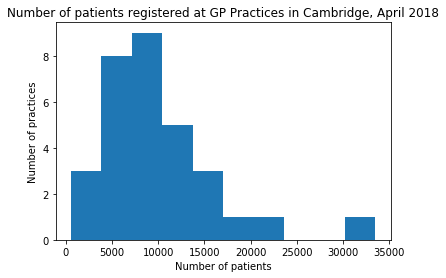

```python
#hist of Cambridge pop
#min_x = cbg.groupby('CODE')['NUMBER_OF_PATIENTS'].first().quantile(.01)
#max_x = cbg.groupby('CODE')['NUMBER_OF_PATIENTS'].first().quantile(.99)
_ = plt.hist(cbg.groupby('CODE')['NUMBER_OF_PATIENTS'].first())
#_ = plt.xlim(min_x, max_x)
_ = plt.title('Number of patients registered at GP Practices in Cambridge, April 2018')
_ = plt.xlabel('Number of patients')
_ = plt.ylabel('Number of practices')
```

#### Prescriptions

```python
# group prescribing data by practice
cbg_prac_grouped = cbg.drop(['ACTCOST'], axis=1).groupby(['CODE', 'NAME', 'NUMBER_OF_PATIENTS']).sum().reset_index('NUMBER_OF_PATIENTS')

# group prescribing data by BNFCODE
cbg_bnf_grouped = cbg.drop(['NUMBER_OF_PATIENTS', 'ACTCOST'], axis=1).groupby(['BNFCODE', 'BNFNAME']).sum().reset_index('BNFCODE')
```

```python
# summary of Cambridge GP scrips
print('Within Cambridge ', np.sum(cbg['ITEMS']), ' prescriptions for ', cbg['BNFCODE'].nunique(), ' different items were given out in April 2018 ',
      'at a total cost of £', round(np.sum(cbg['TOTALCOST']),2), '. This means across Cambridge the average number of prescriptions per patient was ',
      round(np.sum(cbg['ITEMS']) / cbg.groupby('CODE')['NUMBER_OF_PATIENTS'].first().sum(), 2), '. On average each patient cost £',
      round(np.sum(cbg['TOTALCOST']) / cbg.groupby('CODE')['NUMBER_OF_PATIENTS'].first().sum(),2), ' with each drug costing on average £',
      round(np.mean(cbg['ACTCOST']),2),
      sep = '')

cbg.groupby('CODE').first().describe()
```

```
Within Cambridge 344645 prescriptions for 5683 different items were given out in April 2018 at a total cost of £67370054.56. This means across Cambridge the average number of prescriptions per patient was 1.11. On average each patient cost £216.22 with each drug costing on average £60.73
```

|  | NUMBER_OF_PATIENTS | ITEMS | ACTCOST | QUANTITY | TOTALCOST |
| --- | --- | --- | --- | --- | --- |
| count | 31.000000 | 31.000000 | 31.000000 | 31.000000 | 31.000000 |
| mean | 10050.935484 | 2.161290 | 16.039355 | 1191.161290 | 48.588387 |
| std | 6275.995708 | 2.146265 | 20.782409 | 1743.296095 | 96.847555 |
| min | 568.000000 | 1.000000 | 1.120000 | 24.000000 | 1.820000 |
| 25% | 6099.500000 | 1.000000 | 2.955000 | 275.000000 | 2.955000 |
| 50% | 9063.000000 | 1.000000 | 5.980000 | 500.000000 | 7.580000 |
| 75% | 12172.500000 | 2.500000 | 18.440000 | 1075.000000 | 35.840000 |
| max | 33501.000000 | 9.000000 | 85.510000 | 8110.000000 | 383.130000 |

When looking at the average of practices (as opposed to the population overall) we can see that there was large range in the average number and total cost of prescriptions across the practices.

There is considerable variation between practices in the number of items prescribed and the cost of the items prescribed. There could be several reasons for this such as number of patients and type of medications prescribed. To explore these differences we can look at prescriptions by the registered population.

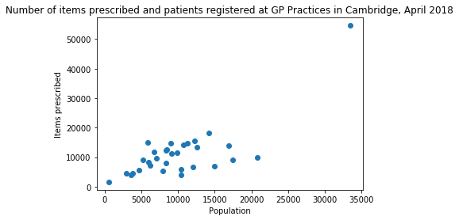

```python
# scatter of pop vs scrips
_ = plt.scatter(cbg_prac_grouped['NUMBER_OF_PATIENTS'], cbg_prac_grouped['ITEMS'])
_ = plt.title('Number of items prescribed and patients registered at GP Practices in Cambridge, April 2018')
_ = plt.xlabel('Population')
_ = plt.ylabel('Items prescribed')
```

This suggests much of the variation in the number of items prescribed is due to the number of patients

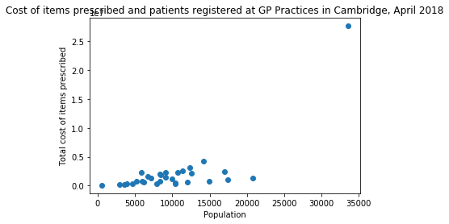

```python
# scatter of pop vs scrip cost
_ = plt.scatter(cbg_prac_grouped['NUMBER_OF_PATIENTS'], cbg_prac_grouped['TOTALCOST'])
_ = plt.title('Cost of items prescribed and patients registered at GP Practices in Cambridge, April 2018')
_ = plt.xlabel('Population')
_ = plt.ylabel('Total cost of items prescribed')
```

However, the cost of prescriptions appears to be less correlated with practice size suggesting there may be differences in prescribing practice between GPs or differences in the needs of patients between practices, for example a tendency to prescribe more expensive items and (as opposed to simple more) would increase costs. Work could be undertaken to explore if more cost-effective items could be substituted for more costly items. There may be particular items that account for much of the expenditure.

```python
# most commonly prescribed
print('The 10 most prescribed items were:')
cbg_bnf_grouped.sort_values('ITEMS', axis=0, ascending=False, kind='quicksort', na_position='last').head(10)
```

```
The 10 most prescribed items were:
```

| BNFNAME | BNFCODE | ITEMS | QUANTITY | TOTALCOST |
| --- | --- | --- | --- | --- |
| Omeprazole_Cap E/C 20mg | 0103050P0AAAAAA | 11675 | 443377 | 6144577.43 |
| Atorvastatin_Tab 20mg | 0212000B0AAABAB | 6416 | 208712 | 1756541.61 |
| Aspirin Disper_Tab 75mg | 0209000A0AAABAB | 5734 | 170129 | 570786.75 |
| Amlodipine_Tab 5mg | 0206020A0AAAAAA | 5462 | 176665 | 2579546.05 |
| Paracet_Tab 500mg | 0407010H0AAAMAM | 4564 | 573883 | 1467760.93 |
| Salbutamol_Inha 100mcg (200 D) CFF | 0301011R0AAAPAP | 4327 | 5279 | 1495281.02 |
| Levothyrox Sod_Tab 100mcg | 0602010V0AABZBZ | 3895 | 137108 | 968612.88 |
| Amitriptyline HCl_Tab 10mg | 0403010B0AAAGAG | 3849 | 196834 | 1397160.88 |
| Simvastatin_Tab 40mg | 0212000Y0AAADAD | 3795 | 113735 | 686841.13 |
| Levothyrox Sod_Tab 25mcg | 0602010V0AABWBW | 3793 | 134374 | 1652622.15 |

```python
# most costly
print('While the ten most costly items were:')
cbg_bnf_grouped.sort_values('TOTALCOST', axis=0, ascending=False, kind='quicksort', na_position='last').head(10)
```

```
While the ten most costly items were:
```

| BNFNAME | BNFCODE | ITEMS | QUANTITY | TOTALCOST |
| --- | --- | --- | --- | --- |
| Omeprazole_Cap E/C 20mg | 0103050P0AAAAAA | 11675 | 443377 | 6144577.43 |
| Fostair_Inh 100mcg/6mcg (120D) CFF | 0302000C0BQAABX | 1725 | 2046 | 5382211.81 |
| Rivaroxaban_Tab 20mg | 0208020Y0AAACAC | 1177 | 31530 | 3534473.06 |
| Amlodipine_Tab 5mg | 0206020A0AAAAAA | 5462 | 176665 | 2579546.05 |
| Tamsulosin HCl_Cap 400mcg M/R | 0704010U0AAAAAA | 2828 | 89515 | 1840208.75 |
| Atorvastatin_Tab 20mg | 0212000B0AAABAB | 6416 | 208712 | 1756541.61 |
| Levothyrox Sod_Tab 25mcg | 0602010V0AABWBW | 3793 | 134374 | 1652622.15 |
| Metformin HCl_Tab 500mg | 0601022B0AAABAB | 3620 | 328345 | 1633485.62 |
| Salbutamol_Inha 100mcg (200 D) CFF | 0301011R0AAAPAP | 4327 | 5279 | 1495281.02 |
| Citalopram Hydrob_Tab 20mg | 0403030D0AAAAAA | 3326 | 114927 | 1469082.46 |

```python
print('The 10 least prescribed items were (note',
      len(cbg_bnf_grouped.loc[cbg_bnf_grouped['ITEMS'] == 1]), 'items are tied for 1):')
cbg_bnf_grouped.sort_values('ITEMS', axis=0, ascending=True, kind='quicksort', na_position='last').head(10)
```

```
The 10 least prescribed items were (note 1524 items are tied for 1):
```

| BNFNAME | BNFCODE | ITEMS | QUANTITY | TOTALCOST |
| --- | --- | --- | --- | --- |
| Mag Carb_Heavy Cap 500mg | 0101010F0AAAUAU | 1 | 30 | 85.51 |
| Resource_2.0 Fibre Liq Feed (6 Flav) | 090402000BBNIA0 | 1 | 20736 | 405.10 |
| Jevity 1.5kcal_Liq | 090402000BBNJA0 | 1 | 30000 | 338.88 |
| Jevity Promote_Liq | 090402000BBNVA0 | 1 | 28000 | 293.18 |
| Ensure TwoCal_Liq (4 Flav) | 090402000BBRZA0 | 1 | 30000 | 308.83 |
| Fresubin Thickened Stage 1_Syr (2 Flav) | 090402000BBSUA0 | 1 | 800 | 8.72 |
| Peptamen Junior Advance_Liq | 090402000BBTDA0 | 1 | 28000 | 418.08 |
| Fresubin Pdr Extra_Pdr Sach 62g (Sbery) | 090402000BBUIA0 | 1 | 28 | 18.19 |
| Nutrison Pack_Protein Plus M/Fibre | 090402000BBNDA0 | 1 | 28000 | 313.69 |
| Fresubin Pdr Extra_Pdr Sach 62g(Vanilla) | 090402000BBUJA0 | 1 | 14 | 9.09 |

```python
# least costly
print('While the ten least costly items were:')
cbg_bnf_grouped.sort_values('TOTALCOST', axis=0, ascending=True, kind='quicksort', na_position='last').head(10)
```

```
While the ten least costly items were:
```

| BNFNAME | BNFCODE | ITEMS | QUANTITY | TOTALCOST |
| --- | --- | --- | --- | --- |
| Haddenham Acc For Veni MTO Short Leg | 21270002508 | 1 | 4 | 0.00 |
| Haddenham Acc For Veni MTO Short Foot | 21270002510 | 1 | 4 | 0.00 |
| Haddenham Acc For Veni MTO Non-Stnd Colr | 21270002513 | 1 | 4 | 0.00 |
| Haddenham Acc For Veni MTO 5cm Strong Pl | 21270002515 | 1 | 4 | 0.00 |
| K-Band 10cm x 4m Ktd Polyam & Cellulose | 20020200803 | 1 | 1 | 0.27 |
| Sure-Amp_Lido HCl Inj 2% 5ml Amp | 1502010J0BLABCB | 1 | 1 | 0.28 |
| Mepore 11cm x 15cm Pfa + Adh Border Dres | 20030100079 | 1 | 1 | 0.33 |
| Jobst Elvarex Acc For L/Extrem Closed To | 21270000118 | 1 | 4 | 0.41 |
| Unspecified Surg Adh Tape 2.5cm x 5m Per | 20100000552 | 1 | 1 | 0.42 |
| Olive Oil_Liq | 190605000AACACA | 2 | 20 | 0.43 |

There is likely to be substantial cost in keeping medications available even if they are not routinely used. It may be possible to stop or reduce the supply of less prescribed items to reduce cost without affecting clinician or patient choice by encouraging the use of alternative products or different pack sizes.